# Exercises: Basic R Programming

David

2017-04-22

# 1. ggplot2 points

Use the `diamond`-dataset (already loaded with `ggplot2`) and

1. look into the relationship between the theoretical max. volume ($vol_{max} = x * y * z$) of a diamond and its price
2. play around with the aesthetic-options of `geom_point` (color, alpha, shape, …)
3. assign the plot to a variable
4. add a title to the plot-variable and plot it
5. save the plot both as a pdf and a png. Open the files and compare their qualities (zoom in)
6. Explain the difference between the following code-snippets:

```r
# 1.
ggplot(df, aes(x = time, y = value, color = symbol)) +
  geom_line()

# 2.
ggplot(df) +
  geom_line(aes(x = time, y = value, color = symbol))

# 3.
ggplot() +
  geom_line(data = df, aes(x = time, y = value, color = symbol))
```

7. Would the following code work?

```r
ggplot(df, aes(x = time, color = symbol)) +
  geom_line(aes(y = value))
```

## Advanced

- Read the doc: http://ggplot2.tidyverse.org/reference/geom_point.html
- Create a new variable that contains the price magnitude (i.e., 100 instead of 197, 300 instead of 315). Plot the carat vs the price and color the points according to the price magnitude. What might be wrong with the picture?
  - Look into factors, set the price magnitude as a factor and plot the graph again.
- what is the difference between `ggplot(df, aes(..., color = "red", ...))` and `ggplot(df, aes(...), color = "red")`? Does that make sense? Why?
- Try to recreate a plot that starts with `ggplot() + geom_point(data = df, aes(...))`. Try using multiple geometrics with distinct data. Compare your results with the slides in the appendix.

# 2. Geometrics

Go to http://docs.ggplot2.org/current/, have a look around and experiment with the different geoms. Use at least point, line, boxplot, density, path, and rug in different plots (try also combining them). Possible datasets are `mpg`, `diamonds`, `faithfuld`, `economics`, `flights`, `airports` (-> `?mpg`), or your own dataset. Combine different geoms with different aesthetics.

Additional ideas include, but are not limited to:

- [stats] Draw a two-dimensional random walk (if unclear, see the pictures of https://en.wikipedia.org/wiki/Random_walk)
- [finance] Use `tidyquant` to download the stock prices (see the vignette or hint below) for the 30 Dow-Jones constituents from 2010 to today and plot their values in a line-chart. Try also to index the stock prices to 100. Also, plot the returns against market returns (Dow-Jones) and finally, plot the density of the returns.
- [finance, market microstructure] Use `tidyquant` to download the stockprices of Alphabet/Google from 2016-01-01 until 2016-12-31 and plot the price as a line, surrounded by a ribbon of high and low. Experiment with geom_line vs. geom_step.
- [world bank] Visualise the development of total population (see library `wbstats`, or hint below) for different selected regions/countries. Then compare the growths of the selected regions/countries with a boxplot. Lastly, compare the population against another statistic in a scatter plot (show the occurences on both axes (geom_rug())).

## Advanced

- [world bank] Use dataseries from the world bank and try to recreate the (wonderful) Gapminder World 2013 (http://static.gapminder.org/files/vector-graphics/gapminder-world-2013.pdf) Load the data directly from the world bank or use `library(gapminder)`.

## Hints:

### Directly Downloading Yahoo Finance Data

```r
library(tidyquant)
# Download the Data directly from Yahoo Finance
df_stocks <- tq_get(c("AAPL", "GOOG"), from = "2016-01-01", to  = "2016-12-31")
```

### Directly Downloading World Bank Data

```r
library(wbstats)
# Download the Data directly from the World Bank
df_pop <- wb(indicator = "SP.POP.TOTL", startdate = 2000, enddate = 2016) %>%
  as_data_frame
```

# 3. Functions

- Create multiple functions and plot them together.

Ideas:

- [trigonometry] Combine `sin`, `cos`, `tan`, and other trigonometric functions (`?Trig`)
- [stats] Plot different distributions with different parameters (hint: `?dnorm`, `?dunif`, `?dt`, `?df`, `?dchisq`, or more general: `?Distributions`)
- [finance] Your lecturer has shown you how to calculate the efficient frontier in the CAPM-context, you use it to calculate the efficient frontier of three assets and get the following formula (Source see footnote: [^1]):
  $$E[R] = \frac{147.8}{4037.6} \pm \sqrt{\left( \frac{147.8}{4037.6} \right)^2 - \frac{6 - 2339.9*\sigma^2}{4037.6}}$$
  Use the function to plot the volatility on the x-axis (given by $\sigma$) and the expected return on the y-axis (given by $E[R]$).

## Advanced

- [fun] There is something called the `batman`-formula, the `heart`-formula, or the `zoidberg-like`-formula (advanced). Look them up and try to graph them.

# 4. Colors

1. Take a subset of the diamond prices, use a scatter plot and color the dots (in an appealing manner) according to their cut.
2. Create a second scatter plot that maps the speed of the flight to the color.
3. Why aren’t the colors displayed properly? Fix it and choose nice colors

```r
ggplot(mpg, aes(x = drv, y = cty, fill = drv)) +
  geom_boxplot() +
  scale_color_manual(values = c("yellow", "gray", "black"))
```

## Advanced

- Polish your previous plot(s) using “right” colors.
- What are factors that you have to consider when choosing colors?
- Besides the mentioned `rainbow()` and `heat.colors()`, find alternative color palettes (hint: colorspace and additionally `hclwizard()`)

# 5. Annotations and Labels

- Take a former plot and properly annotate it (title, x-axis, y-axis, legend, subtitle, caption/source). Experiment with mathematical units/formulas/expressions in the annotations, i.e., $\frac{\$}{m^2}$ (dollars per square meter).
- Use a line-chart of your choice and plot the end-values as labels.
- Use the `mtcars`-dataset to create a scatter plot. Label the cars by name, compare `geom_text` and `geom_label`. Compare that result with `geom_text_repel` and `geom_label_repel` (see Advanced exercise #1). Also, use distinctive colors based on another variable as a fill-color for the labels.

## Advanced

- Look at the library `ggrepel`. What is the difference between `ggplot2::geom_label` and `ggrepel::geom_label_repel`?
- Use `geom_label_repel` or `geom_text_repel` to annotate a plot (for example write the last price of a stock return to the endpoint of the stock prices (similar to the flash crash plot presented in the first slide deck)).
- Look into graph insets and have a focus-element of the main plot displayed in an inset plot.

# 6. Themes

Look at the library `ggthemes` and brush up your previous graphs with some nice themes.

Also: look at `set_theme(theme_xxx())`. Why would you try to use that over `... + theme_xxx()`?

## Advanced

- Look at a way to create your own theme.

# 7. Facets

Find the difference between a `facet_grid` and a `facet_wrap`. Use the datasets to plot different facets.

- Use the flights dataset and explore the delays a flight experiences based on the departure times (i.e., with `geom_points` and `geom_smooth`). Expand the plot by using facets, either weekdays individually or use a binary classifier (weekdays/weekends).
- Repeat the analysis but look at origin airports.
- Change and improve the formatting of the facet labels.

# 8. Maps

Use your previous knowledge to create:

- A map of the flight-connections. (try linear flight-paths, vs. shortest flight-paths aka. great circle)
- Add the lines for the US-states (`map_data("states)`)
- Create a facet for each origin airport.
- Instead of using a polygon, use google maps, or an alternative map as a background (read the introduction to `ggmap`).

## Advanced

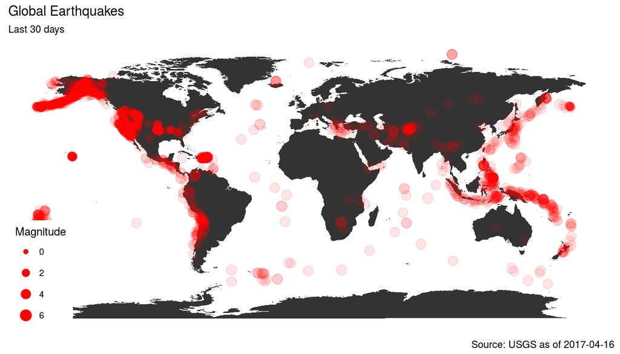

[^1]: Example taken from: https://datashenanigan.wordpress.com/2016/05/24/a-gentle-introduction-to-finance-using-r-efficient-frontier-and-capm-part-1/
[^2]: For more information see: https://earthquake.usgs.gov/earthquakes/feed/v1.0/csv.php